# GTEx data: can we compare CorShrink with corpcor and Glasso?

Kushal K Dey

5/12/2017

Corhrink is an ideal choice for shrinking tissue-tissue correlation matrix in GTEx data, because these correlations are computed over varying number of samples for different tissues. `corpcor` is designed to take a data matrix as input, whereas the input for glasso is a covariance matrix. So, how do we use corpcor in this case to compare with corshrink?

So, if one computes a person by tissues by genes matrix, there will be many NAs corresponding to cells where a person did not contribute a tissue for all genes. In order to empower corpcor, I decided to simulate the NA values per person per gene from the non-NA values in the tissues the person contributed.

The idea behind doing this is that if a person has given very few tissues, we are going to assign a bunch of random samples in the NA places which will bring down the the correlation between tissues that this person contributes to. As number of persons with NA for a tissue grows, there is a likely chance that the correlation will shrink more and more towards zero.

First we look at how the person by tissue table looks like.

```r
person_label=read.table("../data/GTEX_V6/person_identifier_labels_with_numbers.txt");
samples_id <- read.table(file = "../data/GTEX_V6/samples_id.txt")[,1]

samples_person <- sapply(samples_id, function(x) return(paste0(strsplit(as.character(x), "-")[[1]][1:2], collapse ="-")))
tissue_labels <- read.table(file = "../data/GTEX_V6/samples_id.txt")[,3]

table <- xtabs(~ samples_person + tissue_labels)

unique_persons <- unique(samples_person)
unique_tissues <- unique(tissue_labels)
```

The highest number of tissues contributed by a person is

```r
max(rowSums(table))
```

```
## [1] 34
```

```r
unique_persons[which.max(rowSums(table))]
```

```
## [1] "GTEX-1399U"
```

The tissue with most number of contributions is

```r
max(colSums(table))
```

```
## [1] 430
```

```r
which.max(colSums(table))
```

```
## Muscle - Skeletal
##                38
```

Next we build a person by tissue by gene matrix.

```r
library(data.table)
data <- data.frame(fread("../data/GTEX_V6/cis_gene_expression.txt"))
matdata <- t(data[,-c(1,2)])

mat <- matrix(0, length(unique_persons), length(unique_tissues))
person_tissue_genes <- array(0, c(length(unique_persons), length(unique_tissues), dim(matdata)[2]))

for(u in 1:length(unique_persons)){
    index_samp <- which(samples_person == samples_person[u])
    tissue_lab_samp <- tissue_labels[index_samp]
    person_tissue_genes[u, match(tissue_lab_samp, unique_tissues), ] = matdata[index_samp, ]
    cat("We are at person : ", u, "\n")
}

save(person_tissue_genes, file = "../rdas/person_tissue_genes.rda")
```

We load the matrix

```r
person_tissue_genes <- get(load("../rdas/person_tissue_genes.rda"))
```

Next we choose a gene for which we want to compare the tissue correlation structure.

```r
numg <- 100
```

We fill in the NAs by resampling and then take the ranks of the observations for robust inference (getting rid of the library size issues)

```r
mat <- person_tissue_genes[,,numg]
rank_mat <- matrix(0, dim(mat)[1], dim(mat)[2])
for(u in 1:dim(mat)[1]){
  temp <- mat[u, ]
  w <- which(temp == 0);
  mat[u, w] = sample(temp[temp != 0], length(w), replace=TRUE)
  rank_mat[u,] <- rank(mat[u,])
}
```

Now we fit the different correlation shrinkage algorithms (Shafer-Strimmer, GLASSO at different scales and even CorShrink on this new data).

```r
cov_mat <- cov(rank_mat);
system.time(strimmer_sample <- corpcor::cov.shrink(mat))
```

```
## Estimating optimal shrinkage intensity lambda.var (variance vector): 0.0677
##
## Estimating optimal shrinkage intensity lambda (correlation matrix): 0.261
```

```
##    user  system elapsed
##   0.023   0.006   0.030
```

```r
system.time(glasso_sample_005 <- glasso::glasso(cov_mat, rho = 0.05))
```

```
##    user  system elapsed
##   0.169   0.003   0.184
```

```r
system.time(glasso_sample_05 <- glasso::glasso(cov_mat, rho = 0.5))
```

```
##    user  system elapsed
##   0.043   0.000   0.044
```

```r
system.time(glasso_sample_1 <- glasso::glasso(cov_mat, rho = 1))
```

```
##    user  system elapsed
##    0.03    0.00    0.03
```

```r
system.time(glasso_sample_10 <- glasso::glasso(cov_mat, rho = 10))
```

```
##    user  system elapsed
##   0.006   0.000   0.006
```

```r
system.time(cov_sample_ML <-  CorShrink::CorShrinkML(cov2cor(cov_mat), nsamp_mat = 550, sd_boot = FALSE, ash.control = list(mixcompdist = "normal",
                                        nullweight = 1)))
```

```
## ash cor only and ash cor PD matrices are different
```

```
##    user  system elapsed
##   1.153   0.142   1.344
```

Now we plot the image plots of these correlation matrices.

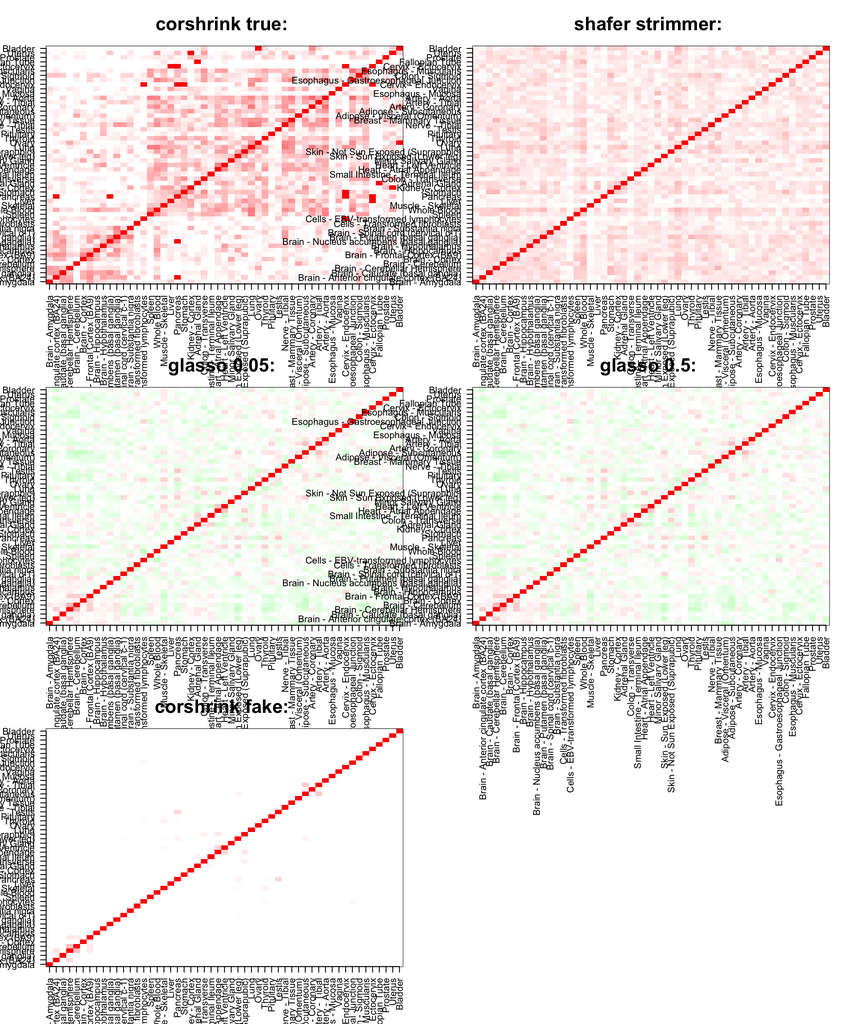

```r
cor_result <- get(load("../rdas/ash_cor_only_gtex_tissues.rda"))

par(mfrow=c(3,2))
col=c(rev(rgb(seq(1,0,length=1000),1,seq(1,0,length=1000))),
      rgb(1,seq(1,0,length=1000),seq(1,0,length=1000)))
image(as.matrix(cor_result[order_index,order_index, numg]),
      col=col, main=paste0("corshrink true: "), cex.main=2,
      xaxt = "n", yaxt = "n", zlim=c(-1,1))
axis(1, at = seq(0, 1, length.out = 53), labels = unique_tissues[order_index], las=2, cex.axis = 1)
axis(2, at = seq(0, 1, length.out = 53), labels = unique_tissues[order_index], las=2, cex.axis = 1)


col=c(rev(rgb(seq(1,0,length=1000),1,seq(1,0,length=1000))),
      rgb(1,seq(1,0,length=1000),seq(1,0,length=1000)))
image(as.matrix(cov2cor(strimmer_sample))[order_index, order_index],
      col=col, main=paste0("shafer strimmer: "), cex.main=2,
      xaxt = "n", yaxt = "n", zlim=c(-1,1))
axis(1, at = seq(0, 1, length.out = 53), labels = unique_tissues[order_index], las=2, cex.axis = 1)
axis(2, at = seq(0, 1, length.out = 53), labels = unique_tissues[order_index], las=2, cex.axis = 1)

col=c(rev(rgb(seq(1,0,length=1000),1,seq(1,0,length=1000))),
      rgb(1,seq(1,0,length=1000),seq(1,0,length=1000)))
image(as.matrix(cov2cor(glasso_sample_005$w))[order_index, order_index],
      col=col, main=paste0("glasso 0.05: "), cex.main=2,
      xaxt = "n", yaxt = "n", zlim=c(-1,1))
axis(1, at = seq(0, 1, length.out = 53), labels = unique_tissues[order_index], las=2, cex.axis = 1)
axis(2, at = seq(0, 1, length.out = 53), labels = unique_tissues[order_index], las=2, cex.axis = 1)


col=c(rev(rgb(seq(1,0,length=1000),1,seq(1,0,length=1000))),
      rgb(1,seq(1,0,length=1000),seq(1,0,length=1000)))
image(as.matrix(cov2cor(glasso_sample_05$w))[order_index, order_index],
      col=col, main=paste0("glasso 0.5: "), cex.main=2,
      xaxt = "n", yaxt = "n", zlim=c(-1,1))
axis(1, at = seq(0, 1, length.out = 53), labels = unique_tissues[order_index], las=2, cex.axis = 1)
axis(2, at = seq(0, 1, length.out = 53), labels = unique_tissues[order_index], las=2, cex.axis = 1)


col=c(rev(rgb(seq(1,0,length=1000),1,seq(1,0,length=1000))),
      rgb(1,seq(1,0,length=1000),seq(1,0,length=1000)))
image(as.matrix(cov_sample_ML$ash_cor_only)[order_index, order_index],
      col=col, main=paste0("corshrink fake: "), cex.main=2,
      xaxt = "n", yaxt = "n", zlim=c(-1,1))
axis(1, at = seq(0, 1, length.out = 53), labels = unique_tissues[order_index], las=2, cex.axis = 1)
axis(2, at = seq(0, 1, length.out = 53), labels = unique_tissues[order_index], las=2, cex.axis = 1)
```